# Project

EU frameworks FP1 - FP7 and Horizon2020 funded research projects

# Introduction

Here we analyse a dataset containing European Union (EU) funded research projects under frameworks

- [FP1](https://data.europa.eu/euodp/en/data/dataset/fp1-cordis) (1984-1987),
- [FP2](https://data.europa.eu/euodp/en/data/dataset/cordis-fp2) (1987-1991),
- [FP3](https://data.europa.eu/euodp/en/data/dataset/cordis-fp3) (1990-1994),
- [FP4](https://data.europa.eu/euodp/en/data/dataset/cordisfp4projects) (1994-1998),
- [FP5](https://data.europa.eu/euodp/en/data/dataset/cordisfp5projects) (1998-2002),
- [FP6](https://data.europa.eu/euodp/en/data/dataset/cordisfp6projects) (2002-2006),
- [FP7](https://data.europa.eu/euodp/en/data/dataset/cordisfp7projects) (2007-2013),
- [Horizon2020](https://data.europa.eu/euodp/en/data/dataset/cordisH2020projects) (2014-2020).

Coordinates for countries are taken [here](https://developers.google.com/public-data/docs/canonical/countries_csv).

The subject (SIC) codes are taken [here](https://data.europa.eu/euodp/en/data/dataset/cordisref-data)

# Data import

```r
#Load some libraries
library(tidyverse) #Data handling, plotting
library(stringr) #String manipulation
library(tm) #Text mining functionality
#library(plotly) #Interactive ggplots
library(tidytext) #Text manipulation
library(SnowballC) #Word stemming
#library(widyr) #Pairwise correlations etc
library(maps) #Drawing maps
library(geosphere) #Computing great cricle lines
library(igraph) #Drawing graphs
library(ggraph) #Drawing graphs
#library(irlba) #Truncated svd on large/sparse matrices
library(wordcloud) #Wordclouds
#library(lvplot)
library(lubridate)
library(magrittr)
```

Read in the datasets using `read_csv2` because the files are `;`-delimited. This is apparently common in Europe because `,` is used as decimal delimiter. Each dataset needs some custom modifications when importing but by using readr we can get them to common shape with little trouble

```r
fp1 <- read_csv2("../dat/eu/fp1.csv",
                 col_types = cols(startDate = col_date(format = "%d/%m/%Y"),
                                  endDate = col_date(format = "%d/%m/%Y"),
                                  totalCost = col_integer(),
                                  ecMaxContribution = col_integer())) %>%
  select(rcn, status, title, startDate, endDate, objective,
         cost = totalCost, contr = ecMaxContribution, fundingScheme, coordinator,
         coordinatorCountry, participants, participantCountries, subjects)

fp2 <- read_csv2("../dat/eu/fp2.csv") %>%
  select(rcn, status, title, startDate, endDate, objective,
         cost = totalCost, contr = ecMaxContribution, fundingScheme, coordinator,
         coordinatorCountry, participants, participantCountries, subjects)

fp3 <- read_csv2("../dat/eu/fp3.csv") %>%
  select(rcn, status, title, startDate, endDate, objective,
         cost = totalCost, contr = ecMaxContribution, fundingScheme, coordinator,
         coordinatorCountry, participants, participantCountries, subjects)

fp4 <- read_csv2("../dat/eu/fp4.csv",
                 col_types = cols(
                   `Start Date` = col_date(format = "%d/%m/%Y"),
                   `End Date` = col_date(format = "%d/%m/%Y"))
                 ) %>%
  select(rcn = RCN, status = Status, title = `Project Title`,
         startDate = `Start Date`, endDate = `End Date`, objective = Objectives,
         cost = `Total Cost`, contr = `Total Funding`, fundingScheme = `Contract Type`,
         coordinatorCountry = `Coordinator Country`,
         participantCountries = `Contractor Country`, subjects = Subject) %>%
  mutate(coordinator = parse_character(NA), participants = parse_character(NA))

fp5 <- read_csv2("../dat/eu/fp5.csv") %>%
  select(rcn, status, title, startDate, endDate, objective,
         cost = totalCost, contr = ecMaxContribution, fundingScheme, coordinator,
         coordinatorCountry, participants, participantCountries, subjects)

fp6   <- read_csv2("../dat/eu/fp6.csv") %>%
  select(rcn, status, title, startDate, endDate, objective,
         cost = totalCost, contr = ecMaxContribution, fundingScheme, coordinator,
         coordinatorCountry, participants, participantCountries, subjects)

fp7   <- read_csv2("../dat/eu/fp7.csv") %>%
  select(rcn, status, title, startDate, endDate, objective,
         cost = totalCost, contr = ecMaxContribution, fundingScheme, coordinator,
         coordinatorCountry, participants, participantCountries, subjects)

h2020 <- read_csv2("../dat/eu/h2020.csv") %>%
  select(rcn, status, title, startDate, endDate, objective,
         cost = totalCost, contr = ecMaxContribution, fundingScheme, coordinator,
         coordinatorCountry, participants, participantCountries, subjects)

projects <- bind_rows(fp1, fp2, fp3, fp4, fp5, fp6, fp7, h2020) %>%
  arrange(startDate) %>%
  mutate(year = year(startDate),
         ratio = contr/cost)

#Clean up
rm(fp1, fp2, fp3, fp4, fp5, fp6, fp7, h2020)

#Change some EU codes into ISO codes
projects <- projects %>%
  mutate(coordinatorCountry = str_replace_all(coordinatorCountry, "UK", "GB")) %>%  #UK
  mutate(coordinatorCountry = str_replace_all(coordinatorCountry, "EL", "GR")) %>% #Greece
  mutate(coordinatorCountry = str_replace_all(coordinatorCountry, "KO", "XK")) %>% #Kosovo
  mutate(coordinatorCountry = str_replace_all(coordinatorCountry, "CS", "RS")) %>%#Serbia
  mutate(participantCountries = str_replace_all(participantCountries, "UK", "GB")) %>%  #UK
  mutate(participantCountries = str_replace_all(participantCountries, "EL", "GR")) %>% #Greece
  mutate(participantCountries = str_replace_all(participantCountries, "KO", "XK")) %>% #Kosovo
  mutate(participantCountries = str_replace_all(participantCountries, "CS", "RS"))

#Country coordinates
# na="" necessary, otherwise country code for Namibia (NA) is interpreted as <NA>
countries <- read_tsv("../dat/eu/countries.csv", na = "")
countries %>% View
#subjects sic codes
sic <- read_csv2("../dat/eu/sic_codes.csv", na = "") %>%
  filter(language == "en") %>%
  select(-language) %>%
  mutate(title = tolower(title),
         code = tolower(code))
```

Glimpse the dataset

```r
projects %>% glimpse
```

```
## Observations: 89,215
## Variables: 16
## $ rcn                  <int> 21680, 8333, 8528, 8816, 8343, 21678, 881...
## $ status               <chr> NA, NA, NA, NA, NA, NA, NA, NA, NA, NA, N...
## $ title                <chr> "Design Rules for the Integration of Indu...
## $ startDate            <date> 1983-07-20, 1983-08-01, 1983-08-01, 1983...
## $ endDate              <date> 1984-07-20, 1988-08-01, 1986-08-01, 1988...
## $ objective            <chr> "The project had two aims: to develop dra...
## $ cost                 <dbl> NA, NA, NA, NA, NA, NA, NA, NA, NA, NA, N...
## $ contr                <dbl> NA, NA, NA, NA, NA, NA, NA, NA, NA, NA, N...
## $ fundingScheme        <chr> NA, NA, NA, NA, NA, NA, NA, NA, NA, NA, N...
## $ coordinator          <chr> "Not Available", "AEG Olympia AG", "NATIO...
## $ coordinatorCountry   <chr> NA, "DE", "IE", "BE", "GB", NA, "BE", NA,...
## $ participants         <chr> NA, "GEC Marconi Research Centre", "Briti...
## $ participantCountries <chr> NA, "GB", "GB", "BE;FR", "GB;DE", NA, "BE...
## $ subjects             <chr> NA, NA, NA, NA, NA, NA, NA, NA, NA, NA, N...
## $ year                 <dbl> 1983, 1983, 1983, 1983, 1983, 1983, 1983,...
## $ ratio                <dbl> NA, NA, NA, NA, NA, NA, NA, NA, NA, NA, N...
```

# Data cleaning, imputation

Let’s look at the individual variables

- rcn

```r
#--- rcn ---
#All projects have unique id
projects %$% any(is.na(rcn)) #FALSE
```

```
## [1] FALSE
```

```r
projects %>% count(rcn) %>% filter(n > 1)
```

```
## # A tibble: 0 × 2
## # ... with 2 variables: rcn <int>, n <int>
```

- status

```r
#--- status ---
projects %>% count(status)
```

```
## # A tibble: 8 × 2
##       status     n
##        <chr> <int>
## 1   Accepted   824
## 2        CAN   533
## 3  Completed 13740
## 4        ONG 22380
## 5     SIGNED  9033
## 6  SUSPENDED     2
## 7 TERMINATED    20
## 8       <NA> 42683
```

- title

```r
projects %>% summarise(n = sum(is.na(title)))
```

```
## # A tibble: 1 × 1
##       n
##   <int>
## 1     0
```

```r
projects %>% count(title, sort = T) %>% filter(n > 1)
```

```
## # A tibble: 655 × 2
##                                                                          title
##                                                                          <chr>
## 1  Fusion technology 1-technology for net 2-blanket technology 3-long-term tec
## 2                                                      Contract of association
## 3                             Fusion thermonucleaire controlee action generale
## 4          Notification of basic support for technology work (ref. Ta-tw2-g01)
## 5  * Fusion technology 1-technology for net 2-blanket technology 3-long-term t
## 6                                          EFDA JET experimental campaign 2003
## 7                                          EFDA JET Experimental Campaign 2002
## 8  Workprogramme related to the missions required for preparing and debriefing
## 9               Notification of preferential support for technology TCP 344-35
## 10                                  GENETIC EFFECTS OF ENVIRONMENTAL CHEMICALS
## # ... with 645 more rows, and 1 more variables: n <int>
```

There seems to be many projects with the same title

- start and end date

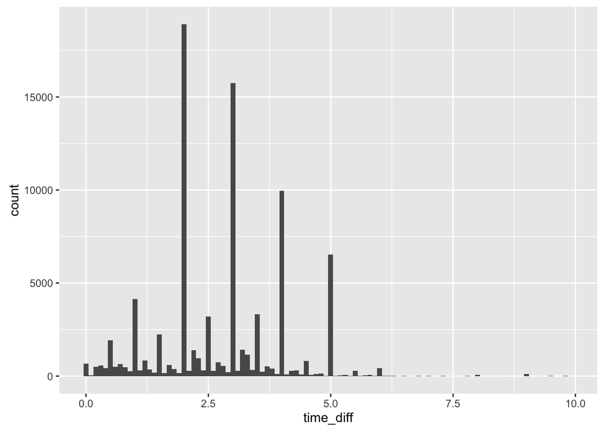

```r
projects %>%
  mutate(time_diff = interval(startDate, endDate) / duration(num = 1, units = "years")) %>%
  filter(time_diff > 0 & !is.na(time_diff)) %>%
  filter(time_diff < 10) %>%
  ggplot(aes(time_diff)) +
  geom_histogram(binwidth = 0.1)
```

There are 4 rows with `time_diff <= 0` and many rows with either date `NA`. Overall many projects have unrealistic end date far in the future. Let’s visualise that

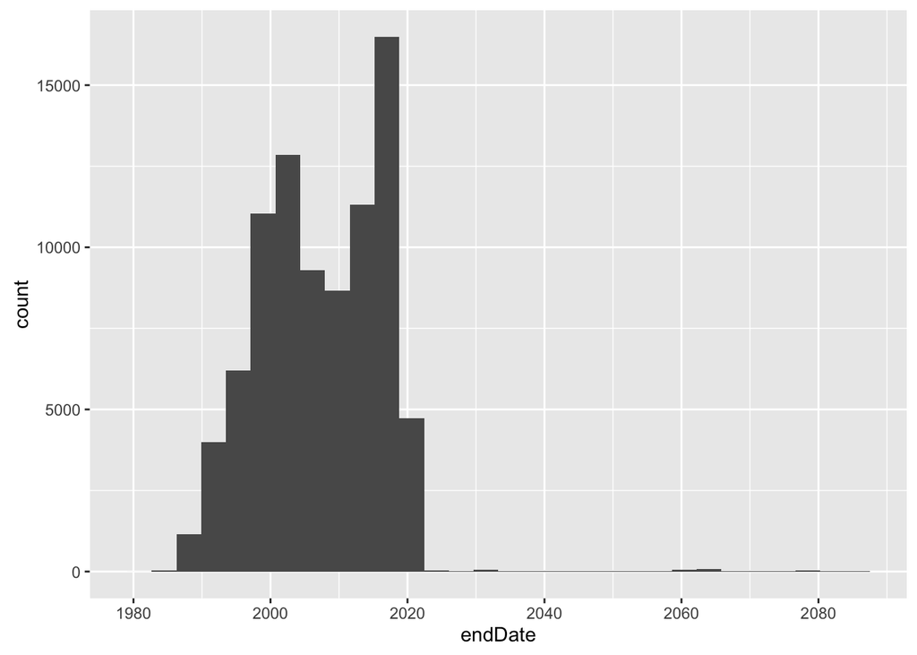

```r
projects %>%
  ggplot(aes(endDate)) + geom_histogram()
```

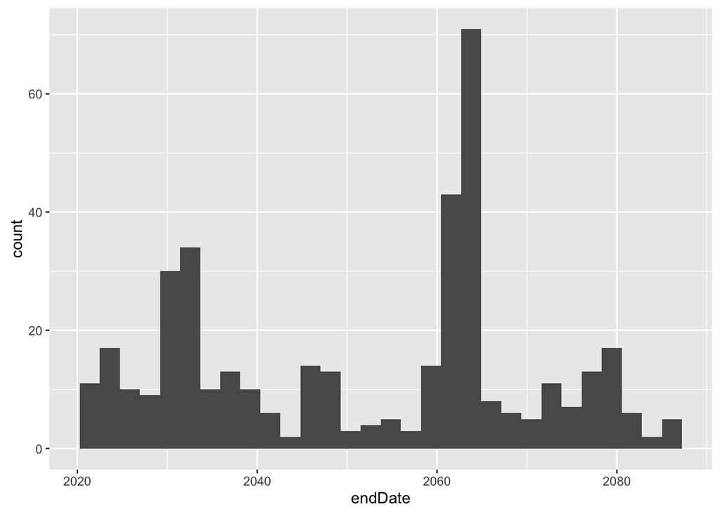

```r
projects %>%
  filter(endDate > "2022-01-01") %>%
  ggplot(aes(endDate)) +
  geom_histogram()
```

I would say that end dates above `2022-01-01` are not trustworthy. Should look into it, because there are many such

# Data exploration

Let’s examine the correlation between project duration and the cost. Let’s just look at projects that run from 0.1 to 10 years and cost more than 100 units

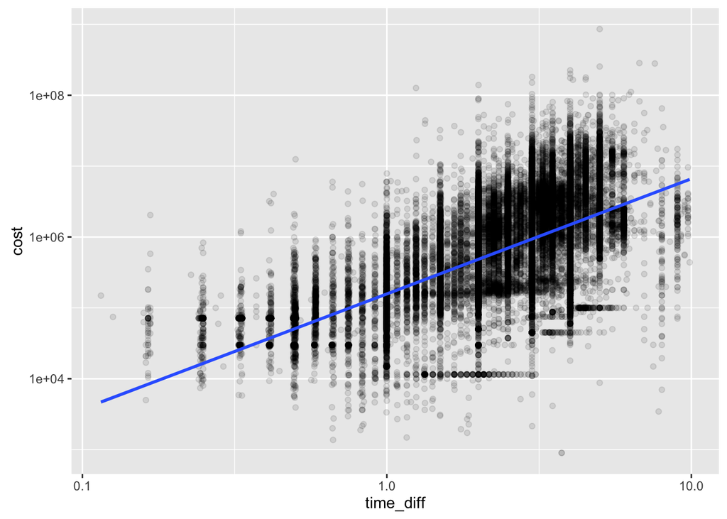

```r
projects %>%
  mutate(time_diff = interval(startDate, endDate) / duration(num = 1, units = "years")) %>%
  filter(between(time_diff, 0.1, 10)) %>%
  filter(between(cost, 1e2, 1e9)) %>%
  ggplot(aes(time_diff, cost)) +
  geom_point(alpha=0.1) +
  geom_smooth(method="lm") +
  scale_y_log10() +
  scale_x_log10()
```

On a log-log scale there seems to be a linear relationship between cost and duration. It is not very surprising.

How does the ratio of contribution to cost vary over time

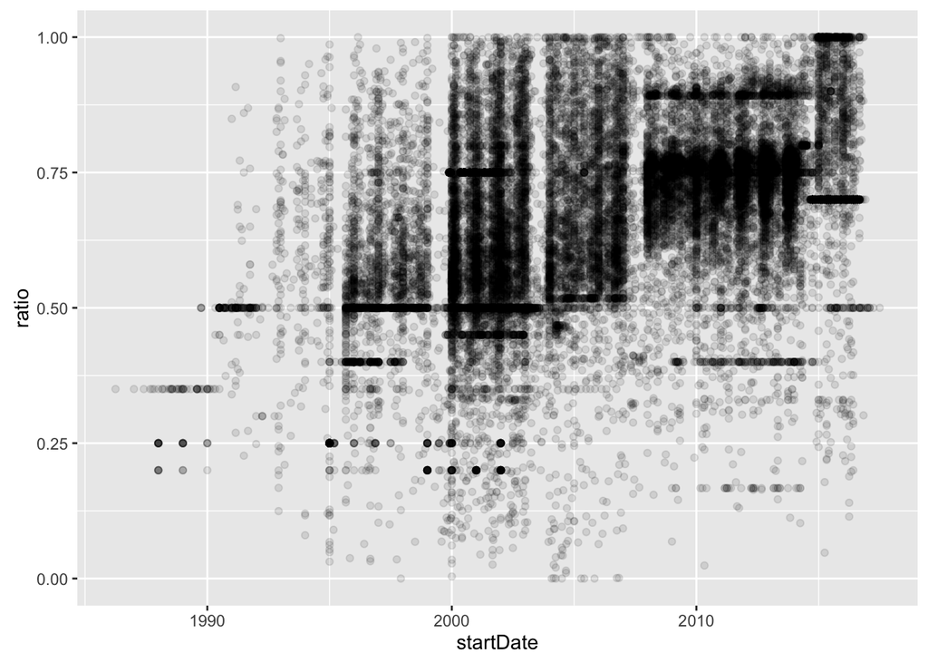

```r
projects %>%
  filter(ratio < 1) %>%
  ggplot(aes(startDate, ratio)) +
  geom_point(alpha=0.1)
```

Median contribution and cost over the years

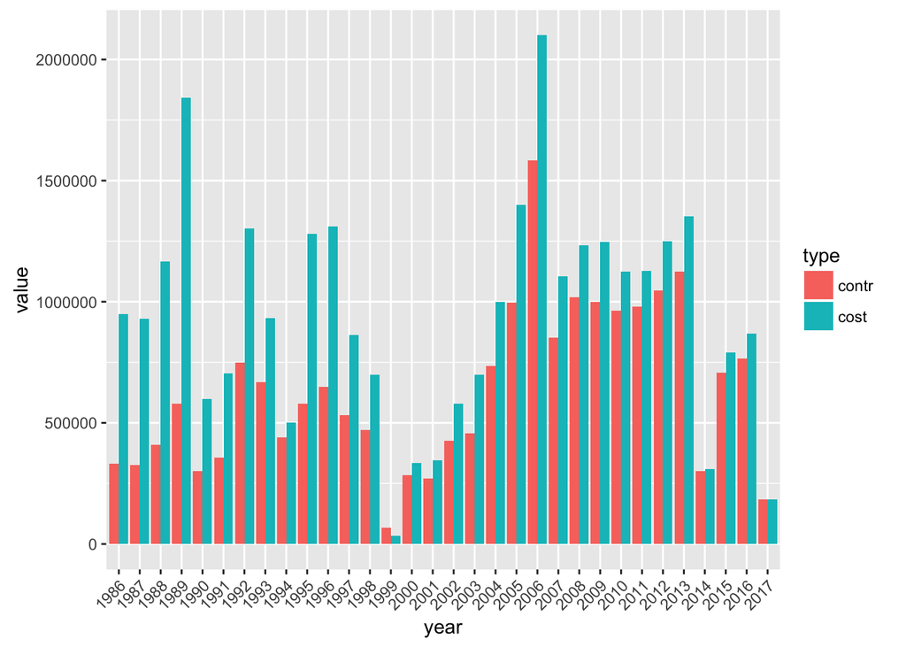

```r
projects %>%
  mutate(year = format(startDate, "%Y")) %>%
  filter(!is.na(startDate)) %>%
  filter(cost < 1e7) %>%
  group_by(year) %>%
  summarise(cost = median(cost, na.rm=T),
            contr = median(contr, na.rm=T)) %>%
  gather(key = "type", value = "value", cost, contr) %>%
  ggplot(aes(year, value, fill = type)) +
  geom_bar(stat="Identity", position = position_dodge()) +
  theme(axis.text.x = element_text(angle = 45, hjust = 1))
```

# Mapping the collaboration network at country level

First let’s create a data frame for connections by separating the participant countries

```r
cnx <- projects %>%
  unnest_tokens(destination, participantCountries, to_lower = FALSE) %>%
  filter(coordinatorCountry != destination) %>%
  left_join(countries, by = c(coordinatorCountry = "country")) %>%
  left_join(countries, by = c(destination = "country")) %>%
  select(-name.x, -name.y) %>%
  group_by(coordinatorCountry, destination) %>%
  summarise(n= n(),
            lon1 = unique(longitude.x),
            lat1 = unique(latitude.x),
            lon2 = unique(longitude.y),
            lat2 = unique(latitude.y)) %>%
  arrange(desc(n)) %>%
  filter(destination != "F") %>% #Probably FR but this connection already exists
  filter(destination != "YU")#Probably former Yugoslavia but let's just drop it now
```

Now that we have our connections let’s visualise them on a graph

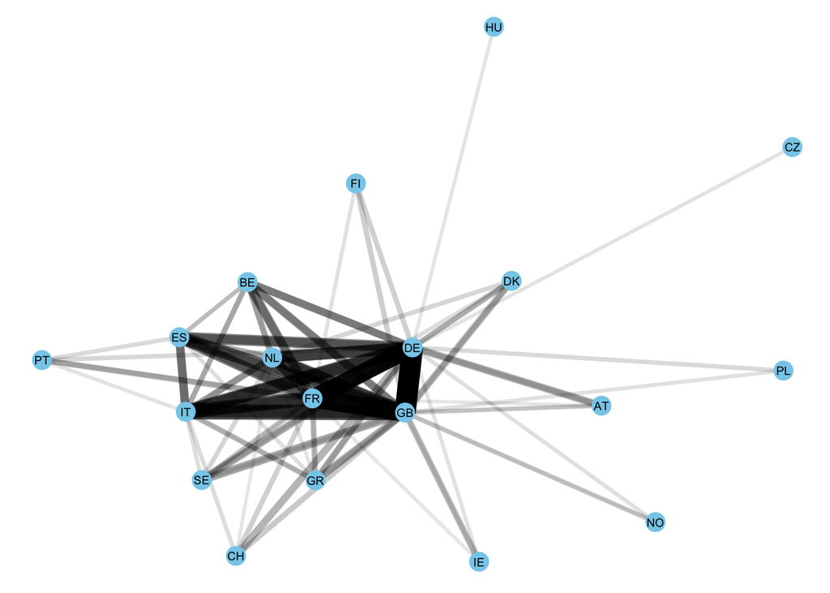

```r
cnx %>%
  filter(n > 500) %>%
  # filter(coordinatorCountry %in% eu) %>%
  # filter(destination %in% eu) %>%
  graph_from_data_frame() %>%
  ggraph(layout = "fr") +
  geom_edge_link(aes(edge_alpha = n, edge_width=n), show.legend = FALSE) +
  geom_node_point(color = "skyblue", size = 5) +
  geom_node_text(aes(label = name), size = 2.5, color = "black") +
  theme_void()
```

Connections as great circle distances

```r
cnx
```

```
## Source: local data frame [2,886 x 7]
## Groups: coordinatorCountry [93]
##
##    coordinatorCountry destination     n      lon1     lat1      lon2
##                 <chr>       <chr> <int>     <dbl>    <dbl>     <dbl>
## 1                  GB          DE  4931 -3.435973 55.37805 10.451526
## 2                  GB          FR  4283 -3.435973 55.37805  2.213749
## 3                  FR          DE  4040  2.213749 46.22764 10.451526
## 4                  DE          GB  3984 10.451526 51.16569 -3.435973
## 5                  DE          FR  3812 10.451526 51.16569  2.213749
## 6                  FR          GB  3741  2.213749 46.22764 -3.435973
## 7                  GB          IT  3461 -3.435973 55.37805 12.567380
## 8                  FR          IT  3200  2.213749 46.22764 12.567380
## 9                  DE          IT  3141 10.451526 51.16569 12.567380
## 10                 GB          NL  3001 -3.435973 55.37805  5.291266
## # ... with 2,876 more rows, and 1 more variables: lat2 <dbl>
```

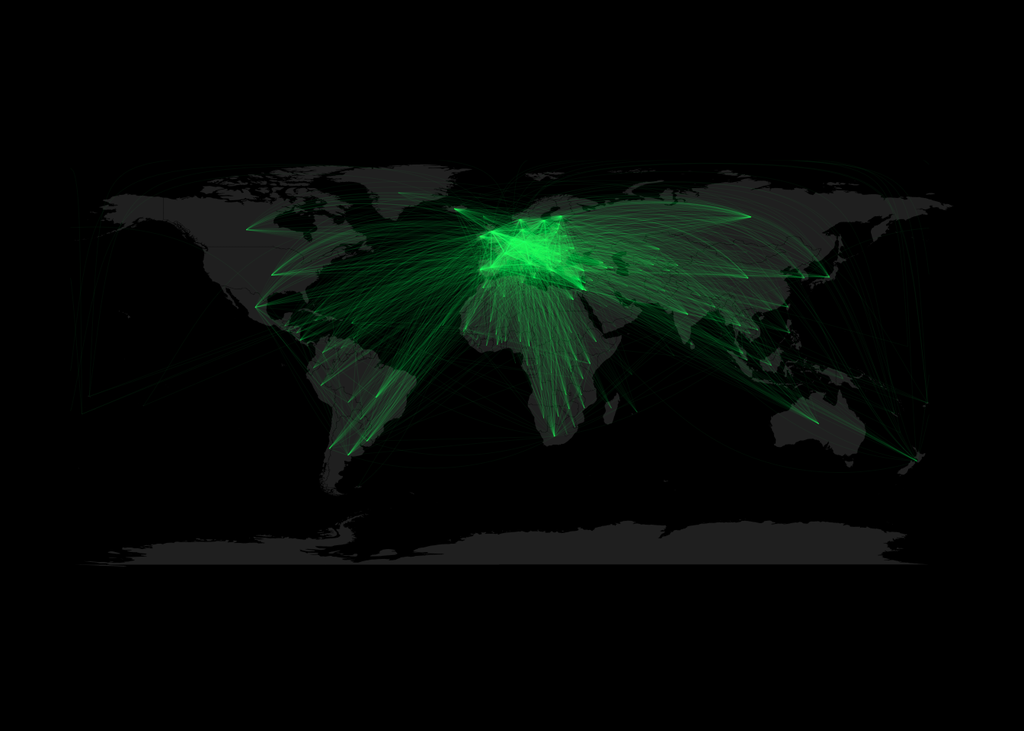

```r
color2hex <- function(color, alpha_hex = "FF"){
  # Turns a color's R name into its hex representation
  c <- col2rgb(color)
  sprintf("#%02X%02X%02X%s", c[1], c[2], c[3], toupper(alpha_hex))
}


map("world", col="#292929", fill=TRUE, bg="#000000", lwd=0.05)

#For alpha gradient
pal <- colorRampPalette(c("#111111", "#aaaaaa")) #Does the interpolation
alpha_vals <- str_extract(pal(256), ".{2}$") #Extract 1 byte

#replace the alpha byte with the interpolated values
colors <- str_replace(color2hex("springgreen", alpha="FF"), ".{2}$", alpha_vals)
alpha_factor <- max(cnx$n)

for(i in 1:nrow(cnx)){
  #Interpolate the great circle lines
  inter2 <- gcIntermediate(c(cnx$lon1[i],
                             cnx$lat1[i]),
                           c(cnx$lon2[i],
                             cnx$lat2[i]), n=100,
                           addStartEnd=TRUE,
                           breakAtDateLine = TRUE)

  colindex <- round( (cnx$n[i] / alpha_factor) * (length(colors)-1) ) + 1
  if(is.list(inter2)){
    lapply(inter2, function(x) lines(x, col=colors[colindex], lwd=0.3))
  }else{
    lines(inter2, col=colors[colindex], lwd=0.3)
  }
  lines(c(cnx$lon1[i], cnx$lon2[i]),
        c(cnx$lat1[i], cnx$lat2[i]), col=colors[colindex], lwd=0.3)
}
```